#### CS 453 - Senior Capstone - SP25

# Higher Education & Success

- An exploration of the factors for student success after higher education

Erica N. Kurpiewski

## 1. Introduction

## 2. The Data

A direct link to the data can be found at the following website.

- https://www.kaggle.com/datasets/programmerrdai/comprehensive-u-s-college-scorecard-data

According the website, the data was collected from the United States Department of Education's College Scorecard. This dataset is not continuously updated as it only contains data spanning from 1996 to 2023. However, more recent data can be found on the College Scorecard website directly (https://collegescorecard.ed.gov/). I believe the data is legitimate because the Department of Education is a reputable branch of the federal government. In addition, the dataset was published on Kaggle under the Massachussets Institute of Technology's liscense. Given the school's reputation as one of the best instituions to attend in the world, I trust that the data compiled in this file is as accurate as possible.

### 2.1 Summary of Variables

The file itself contains individual datasets for every individual academic year spanning 1996 to 2023. In addition, there is data recorded from over 6,000 schools. For the purposes of this project, I will be focusing on the schools located in Pennsylvania.

|  | OPEID | Year | INSTNM | CITY | STABBR | PREDDEG | HIGHDEG | CONTROL | ADM_RATE | UGDS | ... | COUNT_WNE_P11 | MD_EARN_WNE_P11 | SD_EARN_WNE_P11 | COUNT_WNE_INC1_P11 | COUNT_WNE_INC2_P11 | COUNT_WNE_INC3_P11 | GT_THRESHOLD_P11 | MD_EARN_WNE_INC1_P11 | MD_EARN_WNE_INC2_P11 | MD_EARN_WNE_INC3_P11 |
| --- | --- | --- | --- | --- | --- | --- | --- | --- | --- | --- | --- | --- | --- | --- | --- | --- | --- | --- | --- | --- | --- |
| 0 | 708700 | 2016 | Abington Memorial Hospital Dixon School of Nur... | Willow Grove | PA | 1 | 1 | 2 | NaN | 99.0 | ... | NaN | NaN | NaN | NaN | NaN | NaN | NaN | NaN | NaN | NaN |
| 1 | 708700 | 2015 | Abington Memorial Hospital Dixon School of Nur... | Willow Grove | PA | 1 | 0 | 2 | NaN | 217.0 | ... | NaN | NaN | NaN | NaN | NaN | NaN | NaN | NaN | NaN | NaN |
| 2 | 708700 | 2014 | Abington Memorial Hospital Dixon School of Nur... | Willow Grove | PA | 1 | 1 | 2 | NaN | 224.0 | ... | NaN | NaN | NaN | NaN | NaN | NaN | NaN | NaN | NaN | NaN |
| 3 | 708700 | 2013 | Abington Memorial Hospital Dixon School of Nur... | Willow Grove | PA | 1 | 1 | 2 | NaN | 224.0 | ... | NaN | NaN | NaN | NaN | NaN | NaN | NaN | NaN | NaN | NaN |
| 4 | 708700 | 2012 | Abington Memorial Hospital Dixon School of Nur... | Willow Grove | PA | 1 | 1 | 2 | NaN | 233.0 | ... | NaN | NaN | NaN | NaN | NaN | NaN | NaN | NaN | NaN | NaN |

5 rows × 373 columns

```
Missing values:  734
Descriptive Stats:
 count    1361.000000
mean        0.697679
std         0.217694
min         0.000000
25%         0.588000
50%         0.745400
75%         0.854600
max         1.000000
Name: ADM_RATE, dtype: float64
```

|  | OPEID | Year | PREDDEG | HIGHDEG | CONTROL | ADM_RATE | UGDS | UGDS_WHITE | UGDS_BLACK | UGDS_HISP | ... | COUNT_WNE_P11 | MD_EARN_WNE_P11 | SD_EARN_WNE_P11 | COUNT_WNE_INC1_P11 | COUNT_WNE_INC2_P11 | COUNT_WNE_INC3_P11 | GT_THRESHOLD_P11 | MD_EARN_WNE_INC1_P11 | MD_EARN_WNE_INC2_P11 | MD_EARN_WNE_INC3_P11 |
| --- | --- | --- | --- | --- | --- | --- | --- | --- | --- | --- | --- | --- | --- | --- | --- | --- | --- | --- | --- | --- | --- |
| count | 2.095000e+03 | 2095.000000 | 2095.000000 | 2095.000000 | 2095.000000 | 1361.000000 | 2093.000000 | 2093.000000 | 2093.000000 | 2093.000000 | ... | 334.000000 | 334.000000 | 110.000000 | 325.000000 | 323.000000 | 296.000000 | 326.000000 | 325.000000 | 323.000000 | 296.000000 |
| mean | 9.321563e+05 | 2016.778998 | 2.342721 | 2.933652 | 2.038186 | 0.697679 | 2688.061156 | 0.669284 | 0.136898 | 0.069584 | ... | 1183.170659 | 50668.583832 | 45087.136364 | 421.396923 | 417.099071 | 414.861486 | 0.715827 | 46115.741538 | 51763.681115 | 56043.452703 |
| std | 9.769128e+05 | 3.157039 | 0.801719 | 1.090853 | 0.638970 | 0.217694 | 5209.146733 | 0.210669 | 0.157798 | 0.071900 | ... | 2135.490276 | 16028.967150 | 21065.380538 | 711.981073 | 738.198598 | 877.292529 | 0.142827 | 14589.323119 | 14557.144928 | 16196.775160 |
| min | 2.160380e+05 | 2012.000000 | 0.000000 | 0.000000 | 1.000000 | 0.000000 | 5.000000 | 0.000000 | 0.000000 | 0.000000 | ... | 26.000000 | 22344.000000 | 17200.000000 | 17.000000 | 16.000000 | 16.000000 | 0.233300 | 19320.000000 | 25514.000000 | 26238.000000 |
| 25% | 3.293000e+05 | 2014.000000 | 2.000000 | 2.000000 | 2.000000 | 0.588000 | 279.000000 | 0.560300 | 0.046600 | 0.024300 | ... | 286.500000 | 39189.750000 | 33485.500000 | 96.000000 | 108.500000 | 68.750000 | 0.629900 | 36212.000000 | 41676.000000 | 45035.000000 |
| 50% | 3.391000e+05 | 2017.000000 | 3.000000 | 3.000000 | 2.000000 | 0.745400 | 1299.000000 | 0.714600 | 0.079300 | 0.053700 | ... | 641.500000 | 48652.000000 | 38390.000000 | 185.000000 | 230.000000 | 232.500000 | 0.740500 | 42989.000000 | 49463.000000 | 54260.500000 |
| 75% | 1.081400e+06 | 2019.500000 | 3.000000 | 4.000000 | 2.000000 | 0.854600 | 2473.000000 | 0.815300 | 0.155600 | 0.093100 | ... | 1261.750000 | 58746.000000 | 48638.000000 | 430.000000 | 397.500000 | 380.000000 | 0.826550 | 53177.000000 | 58392.000000 | 63690.500000 |
| max | 4.232000e+06 | 2022.000000 | 4.000000 | 4.000000 | 3.000000 | 1.000000 | 74630.000000 | 1.000000 | 0.930600 | 0.727300 | ... | 22830.000000 | 112761.000000 | 150438.000000 | 5458.000000 | 7726.000000 | 9642.000000 | 0.950300 | 101086.000000 | 109546.000000 | 124476.000000 |

8 rows × 131 columns

### Data Cleaning

In the process of exploring this dataset, I had to clean up much of the data and consolidate the datasets. Each individual academic year was it's own spreadsheet, and so I had to add a column to store the year data and then add onto to the main sheet to be used in this project.

The original dataset contained over 3,000 columns, which was far more data than I would need or could feasibly use for this project. Many of the columns contained data regarding the available academic programs offered at each institution, various other specific scenarios such as "Percentage of not first-time students that did not receive an award and enrolled at another institution after leaving this institution within 8 years of entry".

There were also a few schools that, within the time period of 10 years, had little to no data recorded, and thus they were also excluded. These schools include the Academy of Vocal Arts, Geisinger Commonwealth School of Medicine, the International Institute for Restorative Practices, Lake Erie College of Osteopathic Medicine, Philadelphia College of Osteopathic Medicine, and Won Institute of Graduate Studies.

## 3. Exploratory Data Analysis

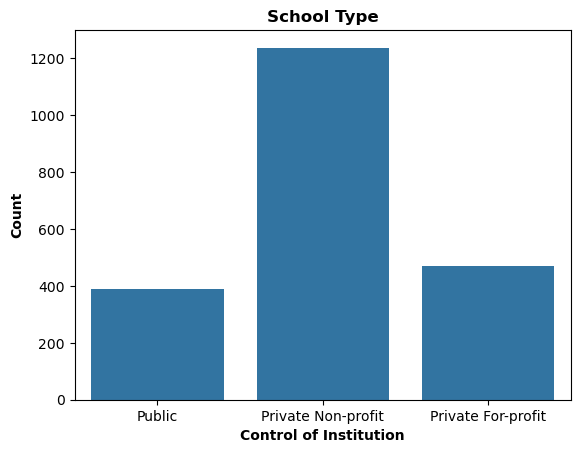

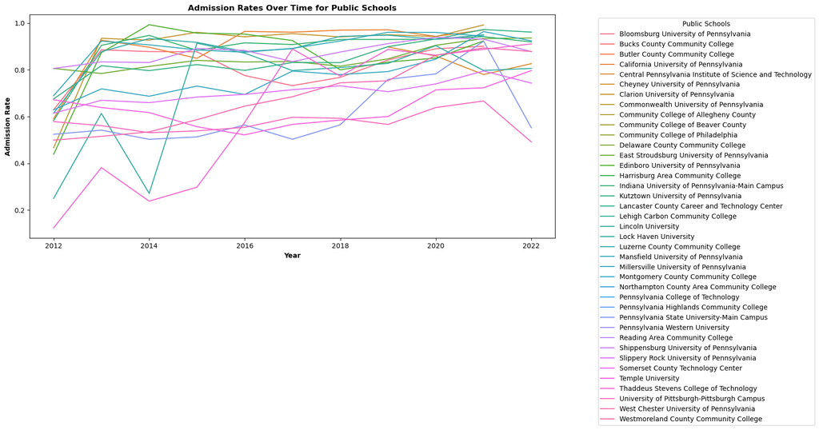

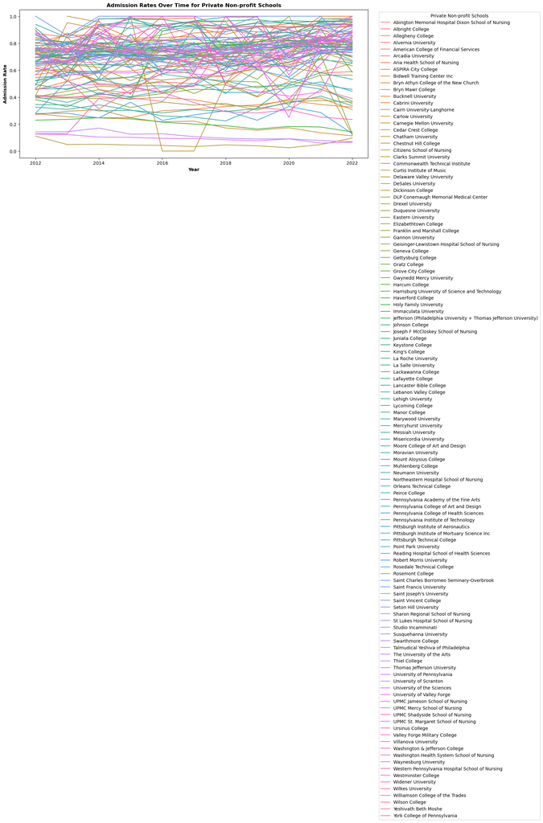

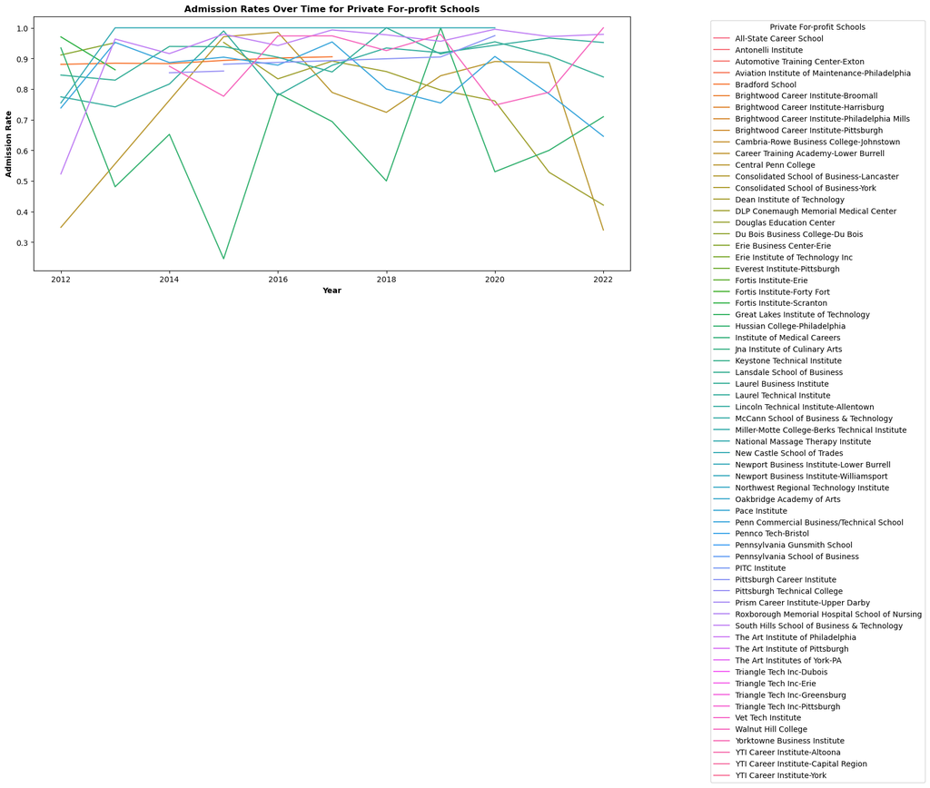